# Linear Models in R

# ANOVA is ALSO a Regression

- **Concept:** We can extend the exact same logic to situations with 3 or more groups.
- **ANOVA:** Also just a special case of the General Linear Model.
- **ANOVA Question:** Is the mean of a continuous variable (Y) different among three or more groups (e.g., A, B, C)?
  - **ANOVA Hypothesis:**
  - $H_0: \mu_A = \mu_B = \mu_C$
  - $H_a$: At least one group mean is different.

# ANOVA: The Conceptual Link

- **More Dummy Variables!**
  - For **k** groups, R creates **k-1** dummy variables.
- **Example (3 Groups: A, B, C):**
  - Reference Group: “Group A”
  - Dummy Variable 1 ($X_1$): 1 if “Group B”, 0 otherwise.
  - Dummy Variable 2 ($X_2$): 1 if “Group C”, 0 otherwise.
- **Regression Model:**
  - $$Y_i = \beta_0 + \beta_1X_1 + \beta_2X_2
    + \epsilon_i$$

# ANOVA: Dummy Coding in the Model

- **Regression Model:**
  - $$Y_i = \beta_0 + \beta_1X_1 + \beta_2X_2
    + \epsilon_i$$
- **Case 1: “Group A” (Reference)**
  - $X_1 = 0$, $X_2 = 0$
  - $Y_i = \beta_0 + \epsilon_i$
  - $\beta_0 = \mu_A$ (Mean of the reference group)
- **Case 2: “Group B”**
  - $X_1 = 1$, $X_2 = 0$
  - $Y_i = (\beta_0 + \beta_1) + \epsilon_i$
  - $\beta_1 = \mu_B - \mu_A$ (Difference from reference)
- **Case 3: “Group C”**
  - $X_1 = 0$, $X_2 = 1$
  - $Y_i = (\beta_0 + \beta_2) + \epsilon_i$
  - $\beta_2 = \mu_C - \mu_A$ (Difference from reference)

# `summary()` vs. `anova()`

- This is a critical concept. When you run `lm()` with a factor, you get two different ways to see the results, and they answer different questions.
- **Dataset:** `iris`
- **DV:** `Sepal.Length`
- **IV:** `Species` (3 levels: setosa, versicolor, virginica)

```r
# 'iris' is built-in
data(iris)
# Run the linear model
model_aov <- lm(Sepal.Length ~ Species, data = iris)
```

# 1. The `summary()` Output (The t-tests)

```r
summary(model_aov)
```

```
##
## Call:
## lm(formula = Sepal.Length ~ Species, data = iris)
##
## Residuals:
##     Min      1Q  Median      3Q     Max
## -1.6880 -0.3285 -0.0060  0.3120  1.3120
##
## Coefficients:
##                   Estimate Std. Error t value Pr(>|t|)
## (Intercept)         5.0060     0.0728  68.762  < 2e-16 ***
## Speciesversicolor   0.9300     0.1030   9.033 8.77e-16 ***
## Speciesvirginica    1.5820     0.1030  15.366  < 2e-16 ***
## ---
## Signif. codes:  0 '***' 0.001 '**' 0.01 '*' 0.05 '.' 0.1 ' ' 1
##
## Residual standard error: 0.5148 on 147 degrees of freedom
## Multiple R-squared:  0.6187, Adjusted R-squared:  0.6135
## F-statistic: 119.3 on 2 and 147 DF,  p-value: < 2.2e-16
```

- **Coefficients:** Shows the $\beta$ estimates.
- `(Intercept)`: 5.006 (Mean of `setosa`, the reference group).
- `Speciesversicolor`: 0.930 (Difference: $\mu_{versicolor} - \mu_{setosa}$).
- `Speciesvirginica`: 1.582 (Difference: $\mu_{virginica} - \mu_{setosa}$).
- **Question Answered:** The p-values are t-tests comparing each group **to the reference**.
- “Is versicolor different from setosa?” (Yes, p < 8.77e-16)
- “Is virginica different from setosa?” (Yes, p < 2e-16)
- **Missing Question:** This *does not* tell us if `versicolor` and `virginica` are different from each other!

# 2. The `anova()` Output (The F-test)

```r
anova(model_aov)
```

```
## Analysis of Variance Table
##
## Response: Sepal.Length
##            Df Sum Sq Mean Sq F value    Pr(>F)
## Species     2 63.212  31.606  119.26 < 2.2e-16 ***
## Residuals 147 38.956   0.265
## ---
## Signif. codes:  0 '***' 0.001 '**' 0.01 '*' 0.05 '.' 0.1 ' ' 1
```

# `summary()` vs. `anova()`: The Takeaway

- `summary(model)`:
  - Gives you the coefficients ($\beta$ values).
  - Provides **t-tests** comparing each group to the **reference group**.
- `anova(model)`:
  - Gives you the overall **F-test**.
  - Answers: “Are there *any* differences *among* the groups?”
  - It does this by comparing your model (`lm(y ~ group)`) to a “null” intercept-only model (`lm(y ~ 1)`).

# ANOVA: How the F-test Comparison Works

- The F-test is a **model comparison**.
- **The Full Model:** `lm(Sepal.Length ~ Species)`
  - Represents the $H_a$ (alternative hypothesis).
  - Assumes group means are different.
  - Prediction for a point = its group mean.
- **The Null Model:** `lm(Sepal.Length ~ 1)`
  - Represents the $H_0$ (null hypothesis).
  - Assumes all group means are equal.
  - Prediction for all points = the grand mean.
- **The F-test Asks:** “Is the reduction in error (SSE) we get by using the Full Model significantly better than the simple Null Model?”

# ANOVA: Illustrating the Model Comparison

We can manually build the null model and compare it to our full model.

```r
# 1. Build the null model (intercept-only)
model_null <- lm(Sepal.Length ~ 1, data = iris)

# 2. Compare the null model to the full model
anova(model_null, model_aov)
```

```
## Analysis of Variance Table
##
## Model 1: Sepal.Length ~ 1
## Model 2: Sepal.Length ~ Species
##   Res.Df     RSS Df Sum of Sq      F    Pr(>F)
## 1    149 102.168
## 2    147  38.956  2    63.212 119.26 < 2.2e-16 ***
## ---
## Signif. codes:  0 '***' 0.001 '**' 0.01 '*' 0.05 '.' 0.1 ' ' 1
```

- **Look at the output!** It is the identical ANOVA table we got from just running `anova(model_aov)`.
- This shows that `anova(model_aov)` is just a shortcut for building an intercept-only null model and comparing it to your full model.

# ANOVA: Visualization

- This plot shows the two models being compared.
- **“Full Model” (Black ’X’s):** The predictions of the full model (the group means).
- **“Null Model” (Red Line):** The prediction of the null model (the grand mean).
- The F-test confirms that the black ’X’s are a significantly better fit to the data than the single red line.

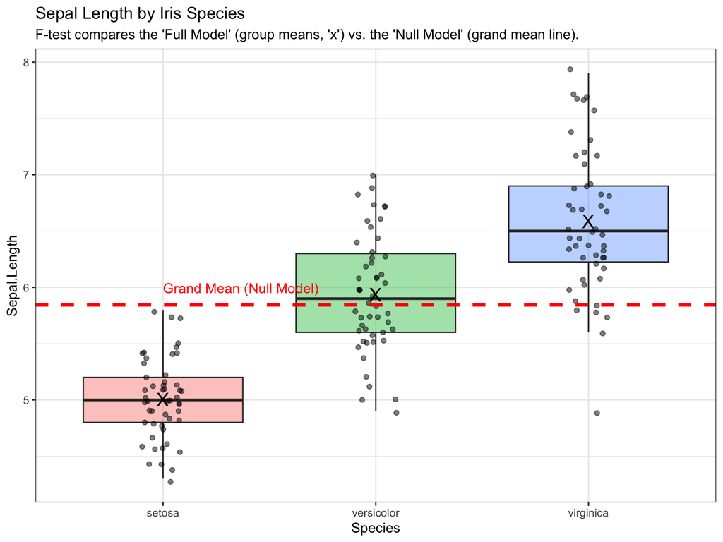

```r
# Get the grand mean for our plot
grand_mean <- mean(iris$Sepal.Length)

ggplot(iris, aes(x = Species, y = Sepal.Length, fill = Species)) +
  geom_boxplot(alpha = 0.4, outlier.shape = NA) +
  geom_jitter(width = 0.1, alpha = 0.5) +
  # This is the "Full Model" prediction (the group means)
  stat_summary(
    fun = "mean", geom = "point", shape = "X", size = 5, color = "black"
  ) +
  # This is the "Null Model" prediction (the grand mean)
  geom_hline(
    yintercept = grand_mean, linetype = "dashed", color = "red", linewidth = 1.2
  ) +
  annotate(
    "text", x = "setosa", y = grand_mean + 0.15,
    label = "Grand Mean (Null Model)", color = "red", hjust = "left"
  ) +
  labs(
    title = "Sepal Length by Iris Species",
    subtitle = "F-test compares the 'Full Model' (group means, 'x') vs. the 'Null Model' (grand mean line)."
  ) +
  theme_bw() +
  theme(legend.position = "none")
```

# ANOVA: From Models to F-values

- The F-statistic is a ratio:
  - $$F = \frac{\text{Variance Explained by
    Groups}}{\text{Variance Unexplained (Residual)}}$$
  - $$F = \frac{\text{Mean Square Model
    (MSM)}}{\text{Mean Square Error (MSE)}}$$
- **Mean Square Model (MSM):** The reduction in error from the Null to the Full model, averaged by its degrees of freedom ($k-1$).
- **Mean Square Error (MSE):** The leftover, unexplained error from the Full Model, averaged by its degrees of freedom ($n-k$).
- If F is large, the “Explained” variance is much bigger than the “Unexplained.”
- If F is near 1.0, the groups explain no more variance than random chance.

# Factorial ANOVA (Interactions)

- **What is it?** An ANOVA with two or more categorical predictors.
- **What are we testing?**
1. **Main Effects:** The overall effect of each predictor separately.
2. **Interaction:** Does the effect of one predictor *depend on* the level of the other?
- **The Logic:** The F-tests for main effects and interactions are just a series of model comparisons, comparing the Sum of Squared Errors (SSE) of a complex model to a simpler one.
- **Notation:**
  - `y ~ group1 + group2` (Additive: Main effects only)
  - `y ~ group1 + group2 + group1:group2` (Main effects and interaction)
  - `y ~ group1 * group2` (Shorthand for main effects and interaction)

# Factorial ANOVA: Defining the Models

- **Dataset:** `ToothGrowth`
  - **IVs:** `supp` (2 levels), `dose` (3 levels, as a factor)
  - **DV:** `len`

We can build a heirarchy of models from simplest to most complex.

```r
# Convert dose to a factor
ToothGrowth$dose <- as.factor(ToothGrowth$dose)

# Model 0: Null Model (Grand Mean)
model_0 <- lm(len ~ 1, data = ToothGrowth)

# Model 3: Additive Model (Main Effects Only)
model_3 <- lm(len ~ supp + dose, data = ToothGrowth)

# Model 4: Interaction Model (Full Factorial)
model_4 <- lm(len ~ supp * dose, data = ToothGrowth)
```

# Factorial ANOVA: Testing the Interaction

- **Question:** Is our Full Interaction Model (Model 4) significantly better than the Additive Model (Model 3)?
  - **Test:** We compare `model_3` and `model_4`.

```r
# Does adding the interaction term (supp:dose) significantly reduce the SSE?
anova(model_3, model_4)
```

```
## Analysis of Variance Table
##
## Model 1: len ~ supp + dose
## Model 2: len ~ supp * dose
##   Res.Df    RSS Df Sum of Sq     F  Pr(>F)
## 1     56 820.43
## 2     54 712.11  2    108.32 4.107 0.02186 *
## ---
## Signif. codes:  0 '***' 0.001 '**' 0.01 '*' 0.05 '.' 0.1 ' ' 1
```

- **Interpretation:**
  - This is the F-test for the `supp:dose` interaction.
  - The F-value (4.1) and p-value (0.022) tell us **YES**.
  - Adding the interaction term significantly reduced the error.
- **Conclusion:** The effect of `dose` on tooth length *depends on* the `supp` type (and vice-versa).

# Factorial ANOVA: `car::Anova()`

- Manually comparing models like this is tedious and can be complex.
- The `car::Anova()` function (with a capital A) is the standard shortcut function for ANOVA.
- It automatically performs the model comparisons and can do so using type III sum of squares.

```r
# Use car::Anova() on the full interaction model
full_model_anova <- car::Anova(model_4,type=3)
full_model_anova
```

```
## Anova Table (Type III tests)
##
## Response: len
##              Sum Sq Df F value    Pr(>F)
## (Intercept)  636.80  1  48.290 4.984e-09 ***
## supp         137.81  1  10.450  0.002092 **
## dose        1649.49  2  62.541 8.753e-15 ***
## supp:dose    108.32  2   4.107  0.021860 *
## Residuals    712.11 54
## ---
## Signif. codes:  0 '***' 0.001 '**' 0.01 '*' 0.05 '.' 0.1 ' ' 1
```

# Factorial ANOVA: Visualization

- When you have a significant interaction, you **must** visualize it.
- Boxplot’s can start to get messy…

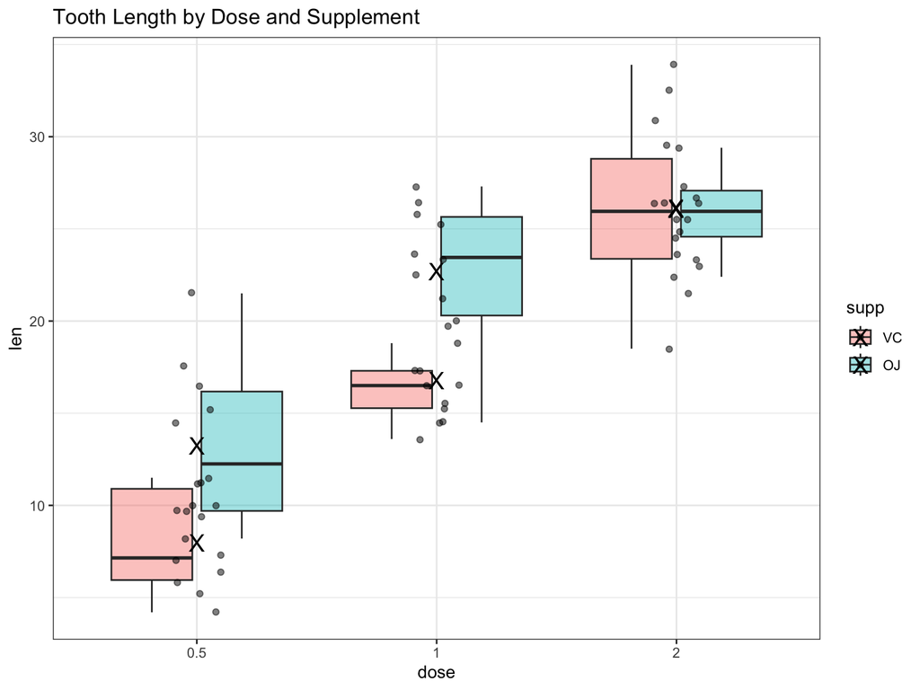

```r
ggplot(ToothGrowth, aes(x = dose, y = len, fill = supp)) +
  geom_boxplot(alpha = 0.4, outlier.shape = NA) +
  geom_jitter(width = 0.1, alpha = 0.5) +
  # This is the "Full Model" prediction (the group means)
  stat_summary(
    fun = "mean", geom = "point", shape = "X", size = 5, color = "black"
  ) +
  labs(
    title = "Tooth Length by Dose and Supplement",
  ) +
  theme_bw()
```

- An “interaction plot” shows how the effect of one variable changes across the levels of the other.
- We plot `dose` on the x-axis and use `color` to show the `supp` lines.

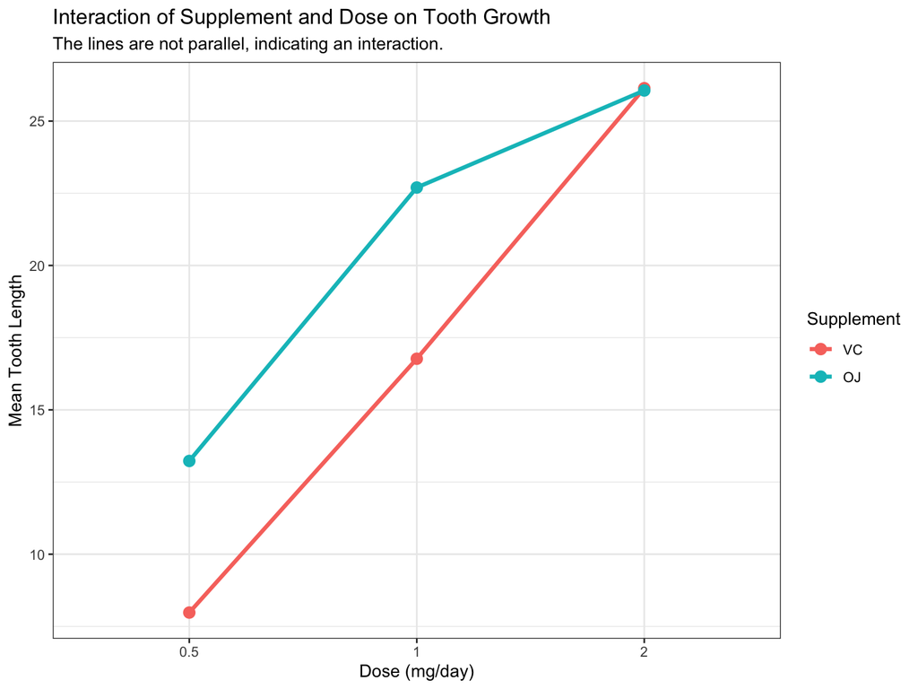

```r
# We need to get the group means to plot
tg_summary <- ToothGrowth %>%
  group_by(supp, dose) %>%
  summarise(mean_len = mean(len))

# Plot the interaction
ggplot(tg_summary, aes(x = dose, y = mean_len, color = supp, group = supp)) +
  geom_line(linewidth = 1.2) +
  geom_point(size = 3) +
  labs(
    title = "Interaction of Supplement and Dose on Tooth Growth",
    subtitle = "The lines are not parallel, indicating an interaction.",
    x = "Dose (mg/day)",
    y = "Mean Tooth Length",
    color = "Supplement"
  ) +
  theme_bw()
```

- **Interpretation:** The lines are not parallel!
  - At doses 0.5 and 1.0, “OJ” produces more growth.
  - At dose 2.0, “VC” and “OJ” are equally effective.
  - The *effect* of `supp` depends on the `dose`. This is the interaction.

# Beyond OLS: Why We Need More

- The `lm()` function is great, but it has one critical limitation: **it assumes all data points are independent.**
  - **Independence:** The residual ($\epsilon_i$) for one data point tells you *nothing* about the residual for any other data point.
- **When is this assumption violated?**
  - **Nested Data:** Students nested within classrooms, classrooms nested within schools. Students in the same class are more similar to each other.
- **Repeated Measures:** Multiple measurements taken from the *same person* over time. These measurements are clearly not independent.
- **Example:** `lme4::sleepstudy` dataset.
- DV: `Reaction` time
- IV: `Days` of sleep deprivation (0-9)
- Data: 10 days of data for 18 different `Subject`s.
- The 10 data points from `Subject 1` are **not** independent of each other.

# Visualizing Non-Independence

- **Problem:** If we run a simple `lm(Reaction ~ Days)`…
- …we are “pooling” all 18 subjects and pretending they are one “super-subject”.
- This single line (`geom_smooth(method="lm")`) is a poor fit.
- It misses the obvious subject-to-subject variability.

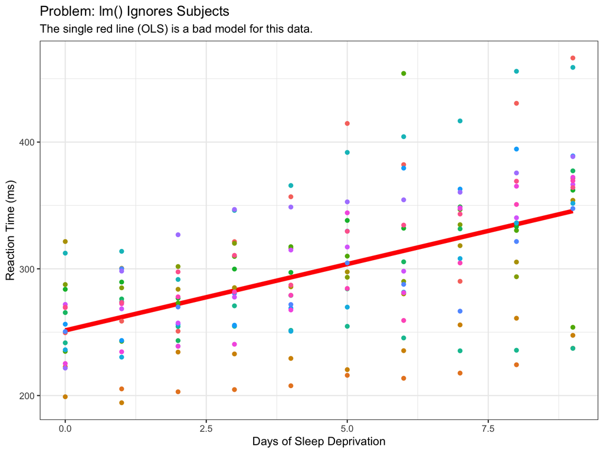

```r
# Load the lme4 package for the data
library(lme4)

ggplot(sleepstudy, aes(x = Days, y = Reaction)) +
  # Plot the "pooled" line, which is what lm() does
  geom_smooth(method = "lm", color = "red", linewidth = 2, se=FALSE) +
  # Add the raw data points, colored by Subject
  geom_point(aes(color = Subject)) +
  labs(
    title = "Problem: lm() Ignores Subjects",
    subtitle = "The single red line (OLS) is a bad model for this data.",
    x = "Days of Sleep Deprivation",
    y = "Reaction Time (ms)"
  ) +
  theme_bw() +
  theme(legend.position = "none") # Too many subjects to show a legend
```

# Visualizing Non-Independence (cont.)

- A better model would fit a *separate line for each subject*.
- We see two key patterns:
  1. **Varying Intercepts:** Some subjects start (Day 0) much faster than others.
  2. **Varying Slopes:** Some subjects get much slower, much faster (steeper slope) than others.
- This is called **non-independent data with random variation in intercepts and slopes.**

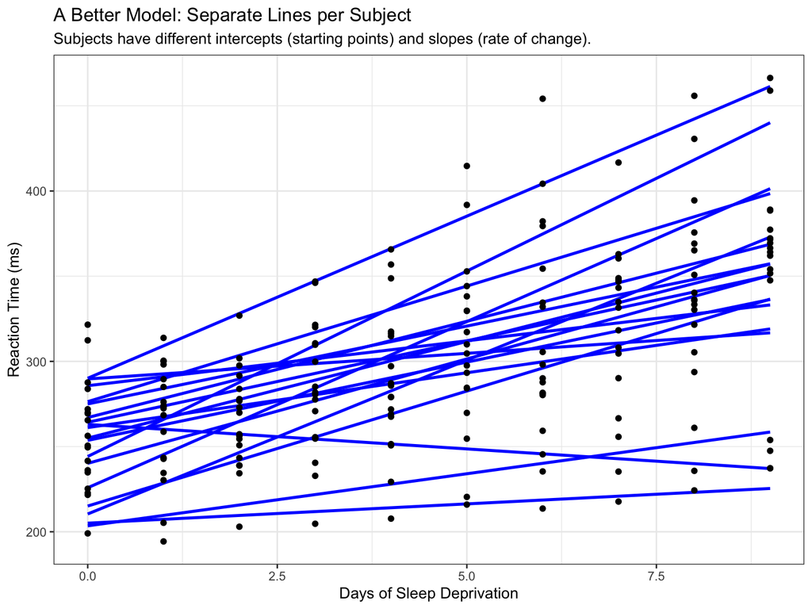

  ```r
  ggplot(sleepstudy, aes(x = Days, y = Reaction, group = Subject)) +
  # Add a separate line for each subject
  geom_smooth(method = "lm", se = FALSE, color = "blue", alpha = 0.5) +
  geom_point() +
  labs(
    title = "A Better Model: Separate Lines per Subject",
    subtitle = "Subjects have different intercepts (starting points) and slopes (rate of change).",
    x = "Days of Sleep Deprivation",
    y = "Reaction Time (ms)"
  ) +
  theme_bw()
  ```

# Solution: Linear Mixed Models (LMM)

- Also called: hierarchical models, multilevel models.
- **R package:** `lme4`
- **Function:** `lmer()`
- **What it does:** It estimates *two* kinds of parameters:
1. **Fixed Effects:** The “average” effects, just like in `lm()`.
- The average intercept ($\beta_0$) for the whole population.
- The average slope ($\beta_1$) for the whole population (e.g., the average effect of `Days`).
2. **Random Effects:** The *variance* of the individual subjects *around* those fixed effects.
- Variance of intercepts: How much do subjects’ starting points differ?
- Variance of slopes: How much do subjects’ slopes (rate of change) differ?

# LMM: R Implementation

- **New Notation:** We add a `( ... | ... )` term for random effects.
- `Reaction ~ Days + (1 + Days | Subject)`
- **Read this as:**
  - `Reaction ~ Days`: This is the **fixed effect** part.
    - Model `Reaction` as a function of `Days`.
  - `+ ( ... | Subject)`: This is the **random effect** part. We are adding random effects *by Subject*.
  - `(1 + Days | ...)`: This part specifies *which* parameters to vary.
  - `1`: Vary the intercept (the `1` is R’s code for an intercept).
  - `Days`: Vary the slope for `Days`.
- **Full Meaning:** “Model Reaction as a function of Days, and let every Subject have their own random intercept and their own random slope for Days.”

# LMM: R Implementation (Code)

```r
# Load lme4 package
library(lme4)
# Load lmerTest package to get p-values
library(lmerTest)

# 1. The "Null" model (Random Intercept Only)
#    - Assumes all subjects have the same slope, but different intercepts.
model_int <- lmer(Reaction ~ Days + (1 | Subject), data = sleepstudy)

# 2. The "Full" model (Random Intercept + Random Slope)
#    - Assumes subjects have different intercepts AND different slopes.
model_full <- lmer(Reaction ~ Days + (1 + Days | Subject), data = sleepstudy)
```

# LMM: Comparing Models

- Which model is better? The one with just random intercepts, or the one with random intercepts *and* slopes?
- We can use `anova()` to compare them.

```r
anova(model_int, model_full)
```

```
## Data: sleepstudy
## Models:
## model_int: Reaction ~ Days + (1 | Subject)
## model_full: Reaction ~ Days + (1 + Days | Subject)
##            npar    AIC    BIC  logLik deviance  Chisq Df Pr(>Chisq)
## model_int     4 1802.1 1814.8 -897.04   1794.1
## model_full    6 1763.9 1783.1 -875.97   1751.9 42.139  2  7.072e-10 ***
## ---
## Signif. codes:  0 '***' 0.001 '**' 0.01 '*' 0.05 '.' 0.1 ' ' 1
```

# LMM: Interpreting the `summary()`

```r
summary(model_full)
```

```
## Linear mixed model fit by REML. t-tests use Satterthwaite's method [
## lmerModLmerTest]
## Formula: Reaction ~ Days + (1 + Days | Subject)
##    Data: sleepstudy
##
## REML criterion at convergence: 1743.6
##
## Scaled residuals:
##     Min      1Q  Median      3Q     Max
## -3.9536 -0.4634  0.0231  0.4634  5.1793
##
## Random effects:
##  Groups   Name        Variance Std.Dev. Corr
##  Subject  (Intercept) 612.10   24.741
##           Days         35.07    5.922   0.07
##  Residual             654.94   25.592
## Number of obs: 180, groups:  Subject, 18
##
## Fixed effects:
##             Estimate Std. Error      df t value Pr(>|t|)
## (Intercept)  251.405      6.825  17.000  36.838  < 2e-16 ***
## Days          10.467      1.546  17.000   6.771 3.26e-06 ***
## ---
## Signif. codes:  0 '***' 0.001 '**' 0.01 '*' 0.05 '.' 0.1 ' ' 1
##
## Correlation of Fixed Effects:
##      (Intr)
## Days -0.138
```

# Assumption Checking

- LMMs share all the assumptions of OLS (linearity, independence of errors *at the lowest level*), but add new ones.
- **Key Assumptions to Check:**
  1. **Homoscedasticity:** Residuals have equal variance.
  2. **Normality of Residuals:** The $\epsilon_i$ terms are normally distributed.
  3. **Normality of Random Effects:** The *new* assumption. The random intercepts and slopes themselves are drawn from a normal distribution.

# Homoscedasticity

- **How to Check:** Plot *residuals* vs. *fitted* values.
- **What we want:** A random “cloud” of points with no pattern.
- **What is bad:** A “funnel” or “megaphone” shape.

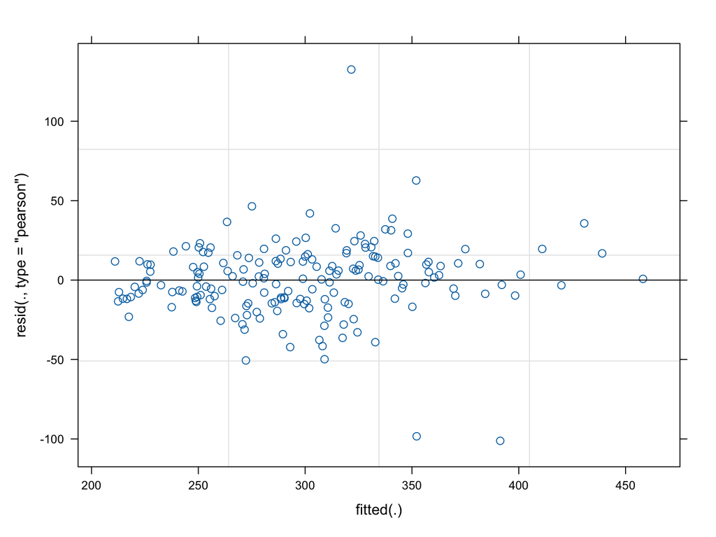

```r
# Plot residuals vs. fitted
plot(model_full)
```

- **Interpretation:** The points look like a random cloud, centered on 0. No obvious funnel shape. This assumption appears met.

# Normality of Residuals

- **How to Check:** A Q-Q (quantile-quantile) plot of the residuals.
- **What we want:** Points should fall along the diagonal line.

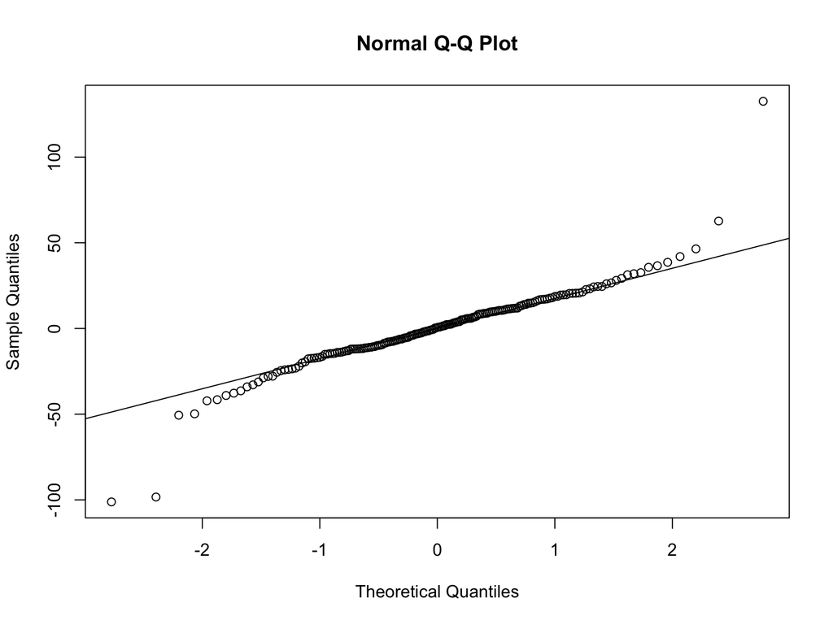

```r
# Q-Q plot of residuals
qqnorm(residuals(model_full))
qqline(residuals(model_full))
```

# LLMAssumption: Normality of Random Effects

- **How to Check:** A Q-Q plot of the *random effects* (`ranef`).
- We use `qqmath()` from the `lattice` package.

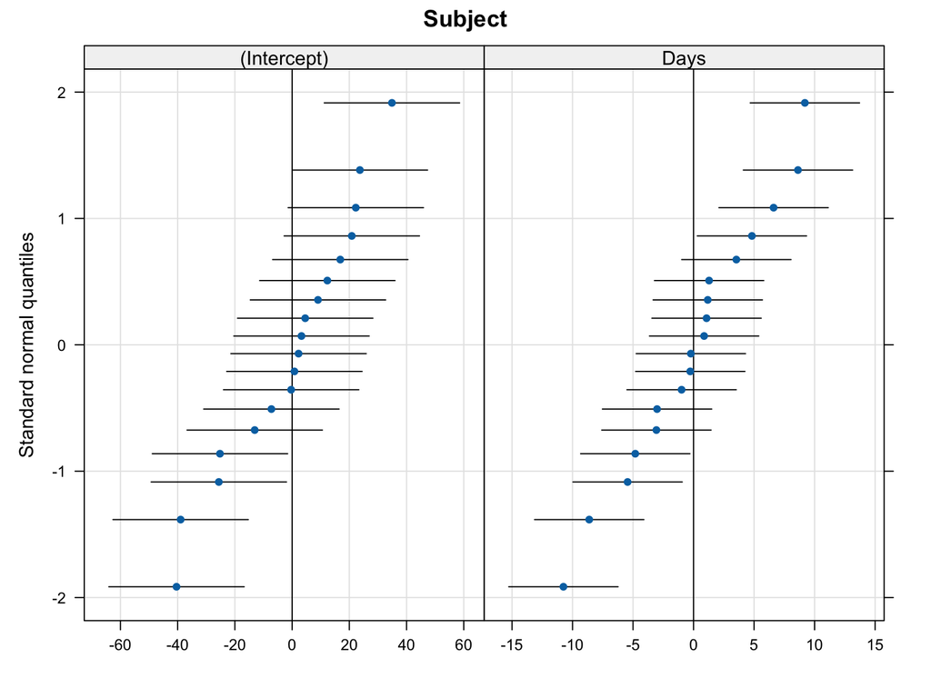

```r
# Load lattice package
library(lattice)

# Create Q-Q plots for each random effect
qqmath(ranef(model_full, condVar = TRUE))
```

```r
#condVar=TRUE tells ranef to model conditional variance
```

- **Interpretation:**
  - This plot shows two panels: one for `(Intercept)` and one for `Days` (the slope).
  - In both panels, the points (our 18 subjects) fall nicely within the confidence bands.
  - This supports the assumption that our random effects are normally distributed.